# Cyclistic Case Study

Piers Gough

09/2024

# Google Data Analytics Capstone Project

## Introduction

This is an optional case study to mark the completion of the Google Data Analytics Professional Certificate.

The framework guiding this task is structured around the following steps: Ask, Prepare, Process, Analyse, Share, and Act.

R Studio was selected over Excel due to the large volume of data in this project; the code used to complete this project is presented below.

## Scenario/Background

You are a junior data analyst working at a company called Cyclistic, a bike-share company located in Chicago. They have over 5800 bicycles and 600 docking stations.

The company generates income through either casual riders (customers who purchase single-ride/full-day passes) or annual memberships.

The director of marketing believes the company’s future success relies on maximising the number of annual memberships.

Therefore, your team wants to understand how casual riders and annual members use Cyclistic bikes differently.

Your job is to provide insights into how these two types of riders differ so the marketing team can design a new strategy to convert casual riders into annual riders.

## Ask

### Questions for Future Marketing Guidance

- How do annual members and casual riders use Cyclistic bikes differently?
- Why would casual riders buy Cyclistic annual memberships?

## Setup and Package Installation

Before data preparation, we must ensure that all the necessary packages are installed and loaded into the session. The following packages were pre-installed using “install.packages()”, however they could not be displayed within the code due to issues with knitting the document:

```r
library(tidyverse)
library(lubridate)
library(janitor)
library(data.table)
```

## Data Preparation

This project used data provided by the bike-sharing system Divvy, Chicago. Although this project references a fictional company named Cyclistic for illustrative purposes, the data used for analysis is real-life data and sourced from Divvy’s records from the year of 2019. This data is made publicly available by Motivate International Inc. under this license: https://divvybikes.com/data-license-agreement

The 2019 data was downloaded in quarters and stored as .csv format. The 2019 data was selected due to data storage constraints within the free software.

Importing the data:

```r
Divvy_Trips_2019_Q1 <- read.csv("~/Downloads/Divvy_Trips_2019_Q1.csv")
Divvy_Trips_2019_Q2 <- read.csv("~/Downloads/Divvy_Trips_2019_Q2.csv")
Divvy_Trips_2019_Q3 <- read.csv("~/Downloads/Divvy_Trips_2019_Q3.csv")
Divvy_Trips_2019_Q4 <- read.csv("~/Downloads/Divvy_Trips_2019_Q4.csv")
```

The headers of “Divvy_Trips_2019_Q2” were renamed to match the other data sets so “rbind()” could function correctly:

```r
colnames(Divvy_Trips_2019_Q2) <- colnames(Divvy_Trips_2019_Q1)
```

Merging the data into a single data frame:

```r
cyclistic_2019_merged <- rbind(Divvy_Trips_2019_Q1, Divvy_Trips_2019_Q2, Divvy_Trips_2019_Q3, Divvy_Trips_2019_Q4)
```

### Data Quality Dimensions

Data quality was assessed with the following criteria:

**Accuracy** - The data was sourced from Divvy, which is a real-bike sharing system in Chicago. This means the data accurately reflects actual bike usage patterns.

**Completeness** - There were no missing values for relevant data for analysis - any incomplete or duplicate data were removed in the final cleaning steps.

**Consistency** - One of the quarterly periods (Q2) had inconsistent headers with the other quarters; it was adjusted in order to enable the rbind() function to work. All relevant data used during analysis had consistent formatting within each column.

**Timeliness** - Although the data is from five years ago (2019), it may serve as a useful comparison for current data when acknowledging the context of COVID-19. The 2019 data provides a baseline understanding of bike-sharing trends before the disruption of COVID-19, and serves as a valuable point of comparison for more recent projects which utilise data from the same bike-sharing company.

**Validity** - All data conforms to the expected type and format.

**Uniqueness** - There are zero duplicate records as identified in the trip ID column.

## Data Processing

### Cleaning

Creating a new data frame to include only those used during analysis:

```r
cyclistic_2019_filtered <- select(cyclistic_2019_merged, "start_time", "end_time", "tripduration", "usertype")
```

Creating a new data frame for the addition of new data:

```r
cyclistic_2019_final <- cyclistic_2019_filtered
```

Ensuring the start time column is in the correct format:

```r
cyclistic_2019_final$start_time <- as.POSIXct(cyclistic_2019_final$start_time, format = "%Y-%m-%d %H:%M:%S")
```

Extracting date and time data into separate columns:

```r
cyclistic_2019_final$month <- month(cyclistic_2019_final$start_time)
cyclistic_2019_final$day_of_week <- wday(cyclistic_2019_final$start_time)
cyclistic_2019_final$hour <- hour(cyclistic_2019_final$start_time)
```

Adding seasonal data based on month data:

```r
cyclistic_2019_final$season <- case_when(
  cyclistic_2019_final$month %in% c(12, 1, 2) ~ "Winter",
  cyclistic_2019_final$month %in% c(3, 4, 5) ~ "Spring",
  cyclistic_2019_final$month %in% c(6, 7, 8) ~ "Summer",
  cyclistic_2019_final$month %in% c(9, 10, 11) ~ "Autumn")
```

Removing commas from trip duration column and changing it to numeric data (from character):

```r
cyclistic_2019_final$tripduration <- gsub(",", "", cyclistic_2019_final$tripduration)
cyclistic_2019_final$tripduration <- as.numeric(cyclistic_2019_final$tripduration)
```

Altering the user type column to match the recent description in the project brief:

```r
cyclistic_2019_final <- cyclistic_2019_final %>%
  mutate(usertype = recode(usertype, "Subscriber" = "Member", "Customer" = "Casual"))
```

Final cleaning of data by removing rows with N/A, duplicates, and trips which are 0 or negative:

```r
cyclistic_2019_final <- na.omit(cyclistic_2019_final)
cyclistic_2019_final <- distinct(cyclistic_2019_final)
cyclistic_2019_final <- cyclistic_2019_final[!(cyclistic_2019_final$tripduration <= 0),]
```

## Analyse

### Overview of Cyclistic Usage Patterns

```r
nrow(cyclistic_2019_final) #every row of data was a unique trip
```

```
## [1] 3814720
```

**Average Ride Length**: 24 minutes 11 seconds

```r
mean_trip_duration <- mean(cyclistic_2019_final$tripduration, na.rm = TRUE)
```

**Busiest Season**: Summer

```r
total_seasonal_trips <- cyclistic_2019_final %>%
  group_by(season) %>%
  summarize(total_trips = n(), .groups = "drop")
busiest_season <- total_seasonal_trips %>%
  filter(total_trips == max(total_trips))
print(busiest_season)
```

```
## # A tibble: 1 × 2
##   season total_trips
##   <chr>        <int>
## 1 Summer     1620993
```

**Busiest Month**: August

```r
total_monthly_trips <- cyclistic_2019_final %>%
  group_by(month) %>%
  summarize(total_trips = n())
busiest_month <- total_monthly_trips %>%
  filter(total_trips == max(total_trips))
print(busiest_month)
```

```
## # A tibble: 1 × 2
##   month total_trips
##   <int>       <int>
## 1     8      589779
```

**Busiest Day of the Week**: Thursday

```r
total_day_of_week_trips <- cyclistic_2019_final %>%
  group_by(day_of_week) %>%
  summarize(total_trips = n())
busiest_day_of_week <- total_day_of_week_trips %>%
  filter(total_trips == max(total_trips))
print(busiest_day_of_week)
```

```
## # A tibble: 1 × 2
##   day_of_week total_trips
##         <int>       <int>
## 1           5      587814
```

**Busiest Time**: 5pm

```r
total_hourly_trips <- cyclistic_2019_final %>%
  group_by(hour) %>%
  summarize(total_trips = n())
busiest_hour <- total_hourly_trips %>%
  filter(total_trips == max(total_trips))
print(busiest_hour)
```

```
## # A tibble: 1 × 2
##    hour total_trips
##   <int>       <int>
## 1    17      474763
```

### Comparison of Cyclistic Usage Patterns in Members vs Casuals

```r
usertype_counts <- table(cyclistic_2019_final$usertype)
print(usertype_counts)
```

```
##
##  Casual  Member
##  880017 2934703
```

- **Average Ride Length**
  - **Member**: 14 minutes 19 seconds
  - **Casual**: 57 minutes 2 seconds

```r
average_ride_length_by_usertype <- cyclistic_2019_final %>%
  group_by(usertype) %>%
  summarize(average_tripduration = mean(tripduration, na.rm = TRUE))
print(average_ride_length_by_usertype)
```

```
## # A tibble: 2 × 2
##   usertype average_tripduration
##   <chr>                   <dbl>
## 1 Casual                  3422.
## 2 Member                   859.
```

- **Busiest Season**
  - **Member**: Summer
  - **Casual**: Summer

```r
trips_by_season_usertype <- cyclistic_2019_final %>%
  group_by(season, usertype) %>%
  summarize(total_trips = n(), .groups = "drop")
busiest_season_by_usertype <- trips_by_season_usertype %>%
  group_by(usertype) %>%
  filter(total_trips == max(total_trips))
print(busiest_season_by_usertype)
```

```
## # A tibble: 2 × 3
## # Groups:   usertype [2]
##   season usertype total_trips
##   <chr>  <chr>          <int>
## 1 Summer Casual        492346
## 2 Summer Member       1128647
```

- **Busiest Month**
  - **Member**: August
  - **Casual**: August

```r
trips_by_month_usertype <- cyclistic_2019_final %>%
  group_by(month, usertype) %>%
  summarize(total_trips = n(), .groups = "drop")
busiest_month_by_usertype <- trips_by_month_usertype %>%
  group_by(usertype) %>%
  filter(total_trips == max(total_trips))
print(busiest_month_by_usertype)
```

```
## # A tibble: 2 × 3
## # Groups:   usertype [2]
##   month usertype total_trips
##   <int> <chr>          <int>
## 1     8 Casual        186741
## 2     8 Member        403038
```

- **Busiest Day of the Week**
  - **Member**: Tuesday
  - **Casual**: Saturday

```r
trips_by_day_of_week_usertype <- cyclistic_2019_final %>%
  group_by(usertype, day_of_week) %>%
  summarize(total_trips = n(), .groups = "drop")
busiest_day_of_week_by_usertype <- trips_by_day_of_week_usertype %>%
  group_by(usertype) %>%
  filter(total_trips == max(total_trips))
print(busiest_day_of_week_by_usertype)
```

```
## # A tibble: 2 × 3
## # Groups:   usertype [2]
##   usertype day_of_week total_trips
##   <chr>          <int>       <int>
## 1 Casual             7      207879
## 2 Member             3      496748
```

- **Busiest Time**
  - **Member**: 5pm
  - **Casual**: 5pm

```r
trips_by_hour_usertype <- cyclistic_2019_final %>%
  group_by(usertype, hour) %>%
  summarize(total_trips = n(), .groups = "drop")
busiest_hour_by_usertype <- trips_by_hour_usertype %>%
  group_by(usertype) %>%
  filter(total_trips == max(total_trips))
print(busiest_hour_by_usertype)
```

```
## # A tibble: 2 × 3
## # Groups:   usertype [2]
##   usertype  hour total_trips
##   <chr>    <int>       <int>
## 1 Casual      17       84433
## 2 Member      17      390330
```

### Visualising Key Differences Between Member and Casual Riders

**Total Rides**

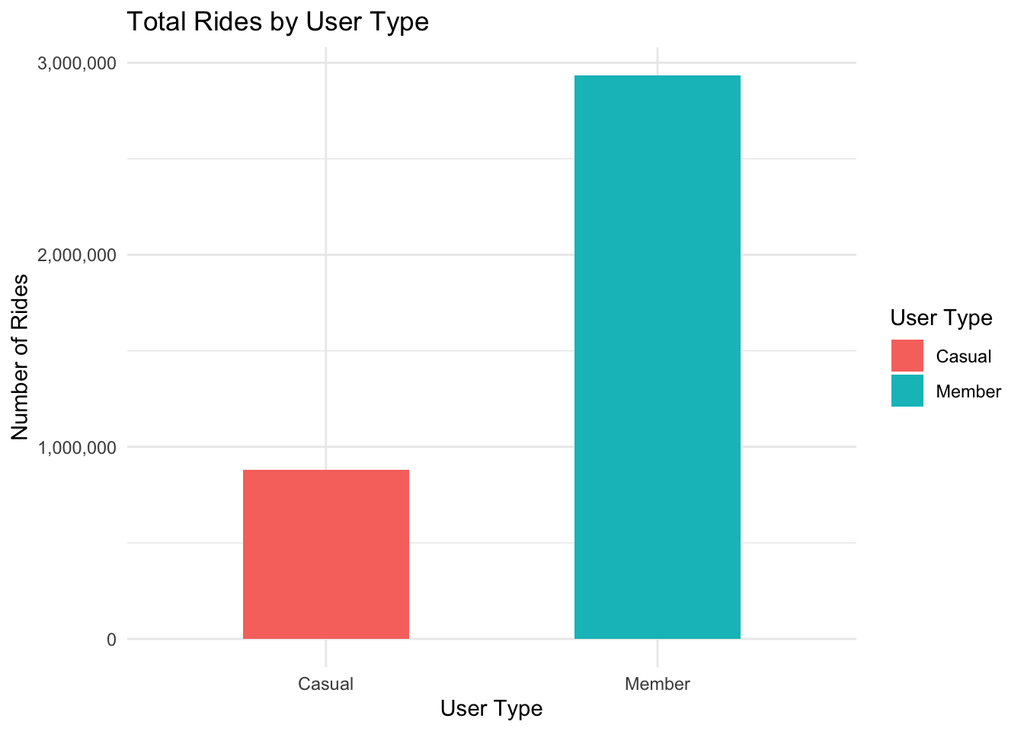

```r
cyclistic_2019_final %>%
  group_by(usertype) %>%
  summarize(number_of_rides = n()) %>%
  ggplot(aes(x = usertype, y = number_of_rides, fill = usertype)) +
  geom_col(width = 0.5, position = position_dodge(width = 0.5)) +
  labs(title = "Total Rides by User Type", x = "User Type", y = "Number of Rides", fill = "User Type") +
  theme_minimal() +
  scale_y_continuous(labels = scales::comma)
```

**Seasonal Rides**

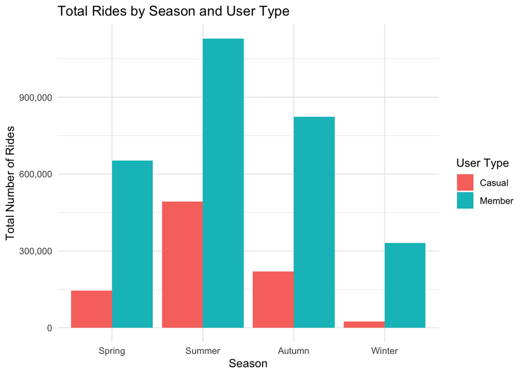

```r
cyclistic_2019_final$season <- factor(cyclistic_2019_final$season, levels = c("Spring", "Summer", "Autumn", "Winter"))
rides_by_season <- cyclistic_2019_final %>%
  group_by(season, usertype) %>%
  summarize(total_rides = n(), .groups = "drop")
ggplot(rides_by_season, aes(x = season, y = total_rides, fill = usertype)) +
  geom_bar(stat = "identity", position = "dodge") +
  labs(
    title = "Total Rides by Season and User Type",
    x = "Season",
    y = "Total Number of Rides",
    fill = "User Type"
  ) +
  theme_minimal() +
  scale_y_continuous(labels = scales::comma)
```

**Monthly Rides**

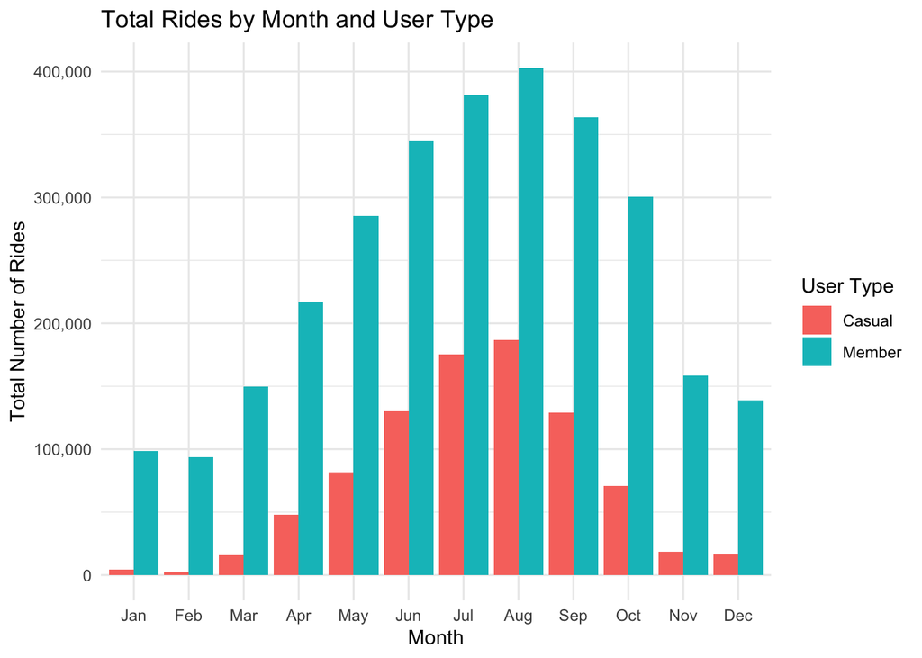

```r
monthly_rides <- cyclistic_2019_final %>%
  filter(!is.na(month)) %>%
  mutate(month_abbr = factor(month, levels = 1:12, labels = month.abb)) %>%
  group_by(month_abbr, usertype) %>%
  summarize(total_rides = n(), .groups = "drop")
ggplot(monthly_rides, aes(x = month_abbr, y = total_rides, fill = usertype)) +
  geom_bar(stat = "identity", position = "dodge") +
  labs(
    title = "Total Rides by Month and User Type",
    x = "Month",
    y = "Total Number of Rides",
    fill = "User Type"
  ) +
  theme_minimal() +
  scale_y_continuous(labels = scales::comma)
```

**Day of the Week Rides**

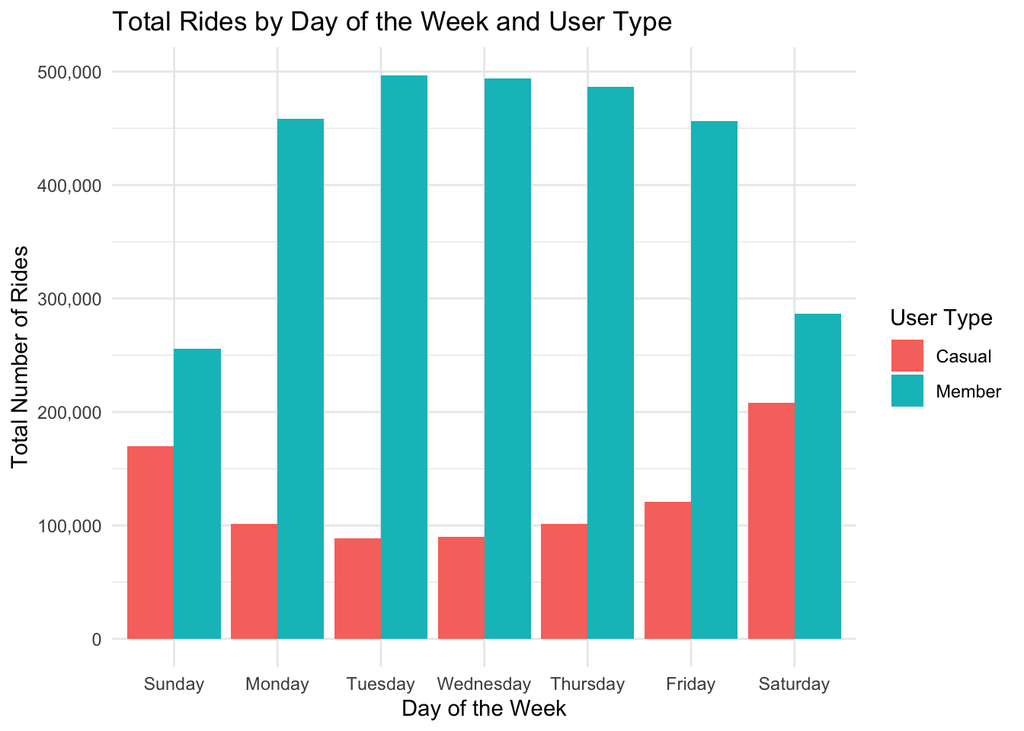

```r
weekday_rides <- cyclistic_2019_final %>%
  filter(!is.na(day_of_week) & day_of_week %in% 1:7) %>%
  mutate(day_of_week_name = factor(day_of_week, levels = 1:7, labels = c("Sunday", "Monday", "Tuesday", "Wednesday", "Thursday", "Friday", "Saturday"))) %>%
  group_by(day_of_week_name, usertype) %>%
  summarize(total_rides = n(), .groups = "drop")
ggplot(weekday_rides, aes(x = day_of_week_name, y = total_rides, fill = usertype)) +
  geom_bar(stat = "identity", position = "dodge") +
  labs(
    title = "Total Rides by Day of the Week and User Type",
    x = "Day of the Week",
    y = "Total Number of Rides",
    fill = "User Type"
  ) +
  theme_minimal() +
  scale_y_continuous(labels = scales::comma)
```

**Hourly Rides**

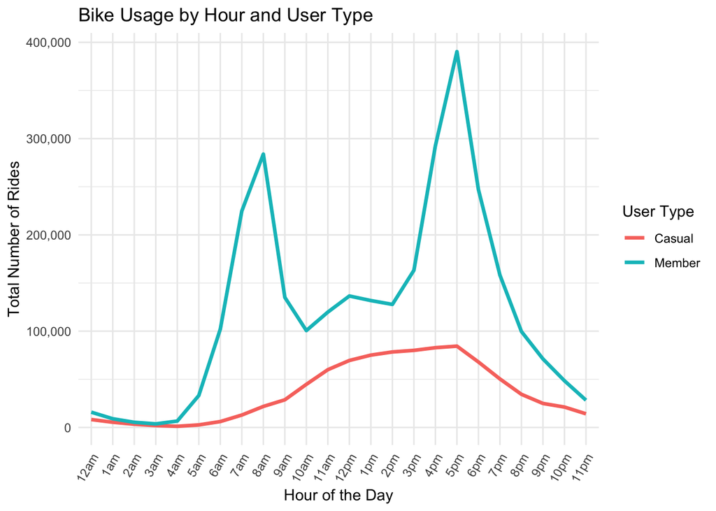

```r
hourly_rides <- cyclistic_2019_final %>%
  filter(!is.na(hour) & hour %in% 0:23) %>%
  mutate(hour_label = factor(hour, levels = 0:23, labels = c("12am", "1am", "2am", "3am", "4am", "5am", "6am", "7am", "8am", "9am", "10am", "11am", "12pm", "1pm", "2pm", "3pm", "4pm", "5pm", "6pm", "7pm", "8pm", "9pm", "10pm", "11pm"))) %>%
  group_by(hour_label, usertype) %>%
  summarize(total_rides = n(), .groups = "drop")
ggplot(hourly_rides, aes(x = hour_label, y = total_rides, color = usertype, group = usertype)) +
  geom_line(linewidth = 1.2) +
  labs(
    title = "Bike Usage by Hour and User Type",
    x = "Hour of the Day",
    y = "Total Number of Rides",
    color = "User Type"
  ) +
  theme_minimal() +
  scale_y_continuous(labels = scales::comma) +
  theme(axis.text.x = element_text(angle = 60, hjust = 1))
```

## Act

### Data Limitations

- Due to privacy issues there is no personal data:
  - Cannot analyse rider frequency or loyalty.
  - Limits insights into customer behaviour trends over time.
  - Unable to track impact of promotions or service changes on individual riders.

### Main Findings

**Average Ride Length** - Casual riders tend to use bikes for much longer on average (~57 mins) compared to members (~14 mins). This suggests that casuals use bikes for leisure-based activities, whereas members use the bikes for task-driven activities, such as as commuting to work or completing errands.

**Weekday Patterns** - Casual bike usage spikes during weekends, whereas member usage remains high during weekdays and declines over the weekend. This further supports the notion that members primarily use the bikes for work-related commuting, whereas casual riders use them for leisure-related activities.

**Hourly Patterns** - One of the strongest indicators is the big spike in member bike usage during morning and evening rush hours, suggesting members primarily use the bikes for commuting. In contrast, casual usage is low during the early hours, gradually increasing (possibly due to the warmer hours of the day) until usage begins to fall in the late afternoon.

**Conclusion** - Overall, the data suggests that members primarily use Cylistic bikes for practical purposes such as commuting, while casual riders tend to use them more for recreational activities. However, as there is no personal information available, we must be cautious with the interpretation of the results as we cannot track individual usage patterns over time. This limits our ability to identify repeat bike users, understand transitions between customer types, and assess whether specific behaviours are driven by unique individuals or spread across a broad range of riders. Without this data we may not fully capture the complexity of user habits.

### Recommendations

- Casual riders tend to use bikes for recreational purposes, particularly during weekends and summer months. As a result, converting them to annual members may not be practical.
- Offering new membership options, such as seasonal passes, may be a more viable strategy to cater for casual riders that use bikes at these specific times.
- However, without personal data, we cannot determine the proportion of casual riders that are local versus tourists. If a large amount of summer rides are made by tourists rather than locals, seasonal memberships may not be appealing to them.
- In this case, creating short-term options such as weekend or week-long passes may be more suitable for tourists or visitors.
- Assuming personal data would still be unavailable in the following year, it may be beneficial to trial seasonal and short-term passes and assess their effectiveness at the end of the year.
- In terms of marketing, popular social media platforms such as TikTok and Instagram could be utilised by partnering with influencers to showcase a day trip using Cyclistic bikes. They could also promote the introduction of the new passes.